# Homework8: Exploring Hypotheses with Fake Data

Carolyn Hanrahan

2023-03-22

## Loading Libraries:

```r
library(sqldf)
library(dplyr)
library(tidyverse)
```

# Question 1

Think about an ongoing study in your lab (or a paper you have read in a different class), and decide on a pattern that you might expect in your experiment if a specific hypothesis were true.

- About the data: built in dataset in R titled “ToothGrowth”. “ToothGrowth data set contains the result from an experiment studying the effect of vitamin C on tooth growth in 60 Guinea pigs. Each animal received one of three dose levels of vitamin C (0.5, 1, and 2 mg/day) by one of two delivery methods, (orange juice or ascorbic acid (a form of vitamin C and coded as VC)”
- Based on the “ToothGrowth” built in dataset in R, I would expect a positive correlation between vitamin C and tooth growth. I would anticipate the treatment group of 2mg/day to have the highest amount of tooth growth compared to the other treatment groups (0.5mg and 1mg)

# Question 2

To start simply, assume that the data in each of your treatment groups follow a normal distribution. Specify the sample sizes, means, and variances for each group that would be reasonable if your hypothesis were true. You may need to consult some previous literature and/or an expert in the field to come up with these numbers.

- sample size: 60

calculating means:

```r
summary <- summary(ToothGrowth)

print(summary)
```

```
##       len        supp         dose
##  Min.   : 4.20   OJ:30   Min.   :0.500
##  1st Qu.:13.07   VC:30   1st Qu.:0.500
##  Median :19.25           Median :1.000
##  Mean   :18.81           Mean   :1.167
##  3rd Qu.:25.27           3rd Qu.:2.000
##  Max.   :33.90           Max.   :2.000
```

Mean for treatment 0.5 mg:

```r
treatment0.5 <- filter(ToothGrowth, dose==0.5)
print(treatment0.5)
```

```
##     len supp dose
## 1   4.2   VC  0.5
## 2  11.5   VC  0.5
## 3   7.3   VC  0.5
## 4   5.8   VC  0.5
## 5   6.4   VC  0.5
## 6  10.0   VC  0.5
## 7  11.2   VC  0.5
## 8  11.2   VC  0.5
## 9   5.2   VC  0.5
## 10  7.0   VC  0.5
## 11 15.2   OJ  0.5
## 12 21.5   OJ  0.5
## 13 17.6   OJ  0.5
## 14  9.7   OJ  0.5
## 15 14.5   OJ  0.5
## 16 10.0   OJ  0.5
## 17  8.2   OJ  0.5
## 18  9.4   OJ  0.5
## 19 16.5   OJ  0.5
## 20  9.7   OJ  0.5
```

```r
TreatmentMean0.5 <- mean(treatment0.5$len)
print(TreatmentMean0.5)
```

```
## [1] 10.605
```

Variance for treatment 0.5 mg:

```r
VarianceTreatment0.5 <- var(treatment0.5$len)
print(VarianceTreatment0.5)
```

```
## [1] 20.24787
```

Standard Deviation for 0.5 mg:

```r
StandardDev0.5 <- sd(treatment0.5$len)
print(StandardDev0.5)
```

```
## [1] 4.499763
```

Mean for Treatment 1 mg:

```r
treatment1 <- filter(ToothGrowth, dose==1)
print(treatment1)
```

```
##     len supp dose
## 1  16.5   VC    1
## 2  16.5   VC    1
## 3  15.2   VC    1
## 4  17.3   VC    1
## 5  22.5   VC    1
## 6  17.3   VC    1
## 7  13.6   VC    1
## 8  14.5   VC    1
## 9  18.8   VC    1
## 10 15.5   VC    1
## 11 19.7   OJ    1
## 12 23.3   OJ    1
## 13 23.6   OJ    1
## 14 26.4   OJ    1
## 15 20.0   OJ    1
## 16 25.2   OJ    1
## 17 25.8   OJ    1
## 18 21.2   OJ    1
## 19 14.5   OJ    1
## 20 27.3   OJ    1
```

```r
TreatmentMean1 <-mean(treatment1$len)
print(TreatmentMean1)
```

```
## [1] 19.735
```

Variance for Treatment 1 mg:

```r
VarianceTreatment1 <- var(treatment1$len)
print(VarianceTreatment1)
```

```
## [1] 19.49608
```

Standard Deviation for Treatment 1 mg:

```r
StandardDev1 <- sd(treatment1$len)

print(StandardDev1)
```

```
## [1] 4.415436
```

Mean for treatment 2 mg:

```r
treatment2 <- filter(ToothGrowth, dose==2)
print(treatment2)
```

```
##     len supp dose
## 1  23.6   VC    2
## 2  18.5   VC    2
## 3  33.9   VC    2
## 4  25.5   VC    2
## 5  26.4   VC    2
## 6  32.5   VC    2
## 7  26.7   VC    2
## 8  21.5   VC    2
## 9  23.3   VC    2
## 10 29.5   VC    2
## 11 25.5   OJ    2
## 12 26.4   OJ    2
## 13 22.4   OJ    2
## 14 24.5   OJ    2
## 15 24.8   OJ    2
## 16 30.9   OJ    2
## 17 26.4   OJ    2
## 18 27.3   OJ    2
## 19 29.4   OJ    2
## 20 23.0   OJ    2
```

```r
TreatmentMean2 <- mean(treatment2$len)
print(TreatmentMean2)
```

```
## [1] 26.1
```

Variance for treatment 2 mg:

```r
VarianceTreatment2 <- var(treatment2$len)
print(VarianceTreatment2)
```

```
## [1] 14.24421
```

Standard Deviation for Treatment 2 mg:

```r
StandardDev2 <- sd(treatment2$len)
print(StandardDev2)
```

```
## [1] 3.77415
```

# Question 3:

Using the methods we have covered in class, write code to create a random data set that has these attributes. Organize these data into a data frame with the appropriate structure.

```r
NormalDistribution0.5 <- rnorm(20, mean=10.605, sd=4.499763)

NormalDistribution1 <- rnorm(20, mean=19.735, sd=4.415436)

NormalDistribution2 <- rnorm(20, mean=26.1, sd=3.77415)



DataFrame <- data.frame(Treatment0.5= NormalDistribution0.5, Treatment1= NormalDistribution1, Treatment2= NormalDistribution2)

print(DataFrame)
```

```
##    Treatment0.5 Treatment1 Treatment2
## 1     12.357749   29.44316   32.11600
## 2     10.289702   17.73246   24.74438
## 3     14.803614   13.96482   29.07295
## 4     18.159648   24.18164   25.37884
## 5     11.751412   13.48820   25.55028
## 6     21.523933   21.96296   20.45039
## 7      9.145490   22.06811   22.56075
## 8      4.545378   20.62488   22.58138
## 9      9.182737   18.81832   25.81756
## 10     7.008129   27.46823   29.53988
## 11     5.839120   17.93730   24.58519
## 12    14.626477   18.95225   25.04730
## 13    14.273090   20.23375   23.65427
## 14    13.727872   25.32787   25.64359
## 15    16.415546   30.38305   28.53034
## 16     8.106404   15.74310   24.76003
## 17    14.489455   16.41914   27.94446
## 18     3.725589   19.52028   31.48964
## 19    11.705271   20.34154   20.67243
## 20     8.321290   26.05900   27.33413
```

```r
Pivot <- pivot_longer(DataFrame,1:3, names_to = "Treatment")
print(Pivot)
```

```
## # A tibble: 60 × 2
##    Treatment    value
##    <chr>        <dbl>
##  1 Treatment0.5  12.4
##  2 Treatment1    29.4
##  3 Treatment2    32.1
##  4 Treatment0.5  10.3
##  5 Treatment1    17.7
##  6 Treatment2    24.7
##  7 Treatment0.5  14.8
##  8 Treatment1    14.0
##  9 Treatment2    29.1
## 10 Treatment0.5  18.2
## # … with 50 more rows
```

```r
Pivot$Treatment<-as.factor(Pivot$Treatment)
```

# Question 4:

Now write code to analyze the data (probably as an ANOVA or regression analysis, but possibly as a logistic regression or contingency table analysis. Write code to generate a useful graph of the data.

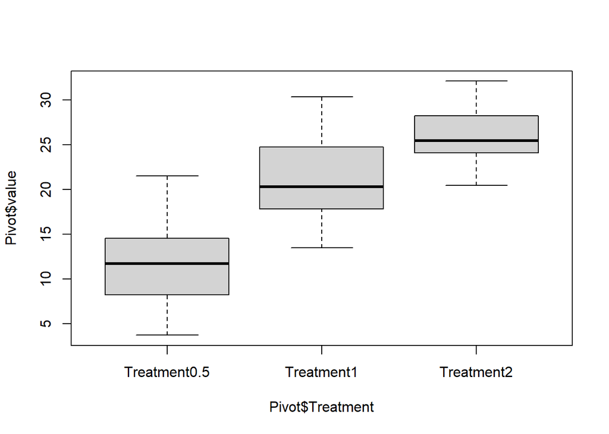

```r
boxplot <- boxplot(formula=Pivot$value~Pivot$Treatment )
```

- it is evident in this boxplot that there is a positive relationship between amount of vitamin C (0.5mg, 1mg, 2mg) and tooth length (y-axis)!

```r
ANOVA <- aov(Pivot$value~Pivot$Treatment)

print(ANOVA)
```

```
## Call:
##    aov(formula = Pivot$value ~ Pivot$Treatment)
##
## Terms:
##                 Pivot$Treatment Residuals
## Sum of Squares         2139.487  1047.833
## Deg. of Freedom               2        57
##
## Residual standard error: 4.287545
## Estimated effects may be unbalanced
```

```r
summary(ANOVA)
```

```
##                 Df Sum Sq Mean Sq F value  Pr(>F)
## Pivot$Treatment  2   2140  1069.7   58.19 1.7e-14 ***
## Residuals       57   1048    18.4
## ---
## Signif. codes:  0 '***' 0.001 '**' 0.01 '*' 0.05 '.' 0.1 ' ' 1
```

# Question 5:

Try running your analysis multiple times to get a feeling for how variable the results are with the same parameters, but different sets of random numbers.

- I tried changing my random normal distribution datasets by changing the sample size from 20 to 50 and found that the ANOVA indicated an even more statistically significant relationship.

# Question 6:

Now begin adjusting the means of the different groups. Given the sample sizes you have chosen, how small can the differences between the groups be (the “effect size”) for you to still detect a significant pattern (p < 0.05)?

```r
NormalDistribution0.5 <- rnorm(20, mean=10.605, sd=4.499763)

NormalDistribution1 <- rnorm(20, mean=11.605, sd=4.415436)

NormalDistribution2 <- rnorm(20, mean=12.605, sd=3.77415)



DataFrame <- data.frame(Treatment0.5= NormalDistribution0.5, Treatment1= NormalDistribution1, Treatment2= NormalDistribution2)

print(DataFrame)
```

```
##    Treatment0.5 Treatment1 Treatment2
## 1      6.285969   5.048039  14.917762
## 2      8.355072   6.954035  17.220283
## 3      3.507708  14.137715   6.866905
## 4     12.823175   4.360308  17.047862
## 5     10.430581  14.032613  14.157059
## 6     17.027110  10.798140  16.532859
## 7      8.021215   9.771004  14.632425
## 8     12.747339  14.047152   7.925211
## 9      5.270486  12.332763  10.625392
## 10    11.495309   6.210427  14.483681
## 11    10.879001   9.973448   9.024651
## 12    10.171550  11.268455  12.444936
## 13    17.432257  14.151073  13.370603
## 14    11.800560  18.860855  10.169120
## 15     9.021397  16.239801  12.669256
## 16     8.555184  14.801812   8.626174
## 17     2.014847  10.252640   2.559366
## 18     4.033314   9.669739   4.860847
## 19    10.696941  13.578010  17.345720
## 20    14.214739  17.348066  17.009794
```

```r
Pivot <- pivot_longer(DataFrame,1:3, names_to = "Treatment")
print(Pivot)
```

```
## # A tibble: 60 × 2
##    Treatment    value
##    <chr>        <dbl>
##  1 Treatment0.5  6.29
##  2 Treatment1    5.05
##  3 Treatment2   14.9
##  4 Treatment0.5  8.36
##  5 Treatment1    6.95
##  6 Treatment2   17.2
##  7 Treatment0.5  3.51
##  8 Treatment1   14.1
##  9 Treatment2    6.87
## 10 Treatment0.5 12.8
## # … with 50 more rows
```

```r
Pivot$Treatment<-as.factor(Pivot$Treatment)
```

```r
ANOVA <- aov(Pivot$value~Pivot$Treatment)

print(ANOVA)
```

```
## Call:
##    aov(formula = Pivot$value ~ Pivot$Treatment)
##
## Terms:
##                 Pivot$Treatment Residuals
## Sum of Squares          64.5975  999.7235
## Deg. of Freedom               2        57
##
## Residual standard error: 4.18796
## Estimated effects may be unbalanced
```

```r
summary(ANOVA)
```

```
##                 Df Sum Sq Mean Sq F value Pr(>F)
## Pivot$Treatment  2   64.6   32.30   1.842  0.168
## Residuals       57  999.7   17.54
```

# Question 7:

Alternatively, for the effect sizes you originally hypothesized, what is the minimum sample size you would need in order to detect a statistically significant effect? Again, run the model a few times with the same parameter set to get a feeling for the effect of random variation in the data.

- I was able to change the sample size for each of the normal distributions until I reached a sample size of 2 before I got a non-statistically significant p-value. Therefore I would need a minimum sample size of 3 to get a statistically significant relationship.

# Question 8:

Write up your results in a markdown file, organized with headers and different code chunks to show your analysis. Be explicit in your explanation and justification for sample sizes, means, and variances.

# Question 9:

- I unfortunately do not have time to repeat this procedure with another type of distribution.